# Lecture 08 Supplemental Notebook

# Scatter plots

```python
births = pd.read_csv('data/baby.csv')
births.head()
```

|  | Birth Weight | Gestational Days | Maternal Age | Maternal Height | Maternal Pregnancy Weight | Maternal Smoker |
| --- | --- | --- | --- | --- | --- | --- |
| 0 | 120 | 284 | 27 | 62 | 100 | False |
| 1 | 113 | 282 | 33 | 64 | 135 | False |
| 2 | 128 | 279 | 28 | 64 | 115 | True |
| 3 | 108 | 282 | 23 | 67 | 125 | True |
| 4 | 136 | 286 | 25 | 62 | 93 | False |

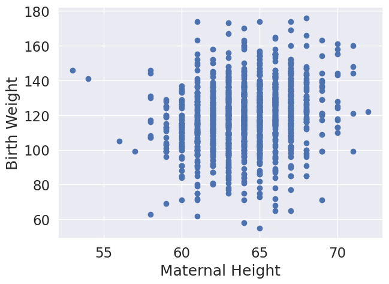

```python
plt.scatter(births['Maternal Height'], births['Birth Weight']);
plt.xlabel('Maternal Height')
plt.ylabel('Birth Weight');
```

Most `matplotlib` functions also accept a `data=` keyword, and when using this mode, you can then refer to x and y as names of columns in the `data` DataFrame, instead of passing the series explicitly:

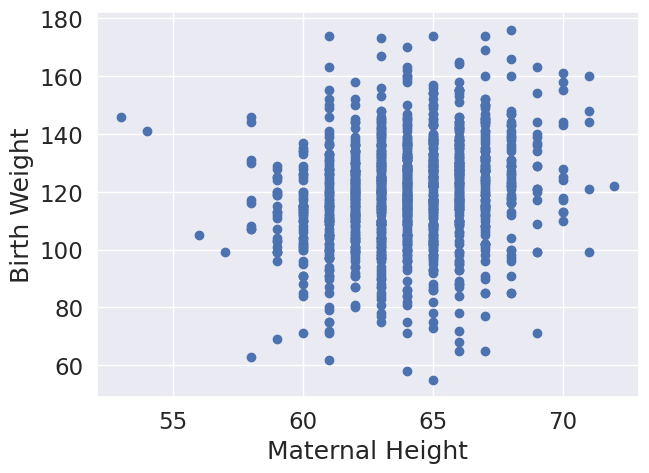

```python
plt.scatter(data = births, x = 'Maternal Height', y = 'Birth Weight');
plt.xlabel('Maternal Height')
plt.ylabel('Birth Weight');
```

This is the seaborn version:

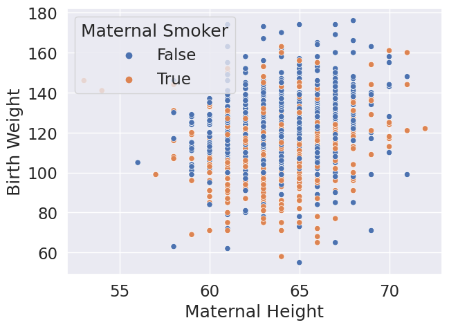

```python
sns.scatterplot(data = births, x = 'Maternal Height', y = 'Birth Weight', hue = 'Maternal Smoker');
```

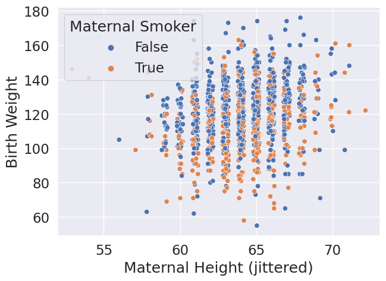

```python
births['Maternal Height (jittered)'] = births['Maternal Height'] + np.random.uniform(-0.2, 0.2, len(births))
fig = sns.scatterplot(data = births, x = 'Maternal Height (jittered)', y = 'Birth Weight', hue = 'Maternal Smoker');
```

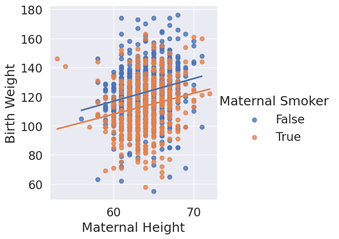

```python
sns.lmplot(data = births, x = 'Maternal Height', y = 'Birth Weight',
           ci = False, hue = 'Maternal Smoker');
```

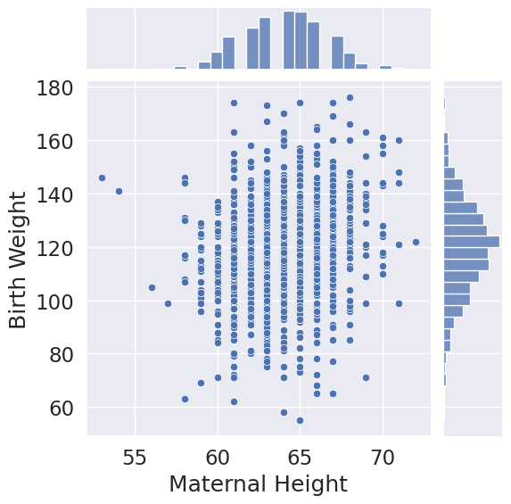

```python
sns.jointplot(data = births, x = 'Maternal Height', y = 'Birth Weight');
```

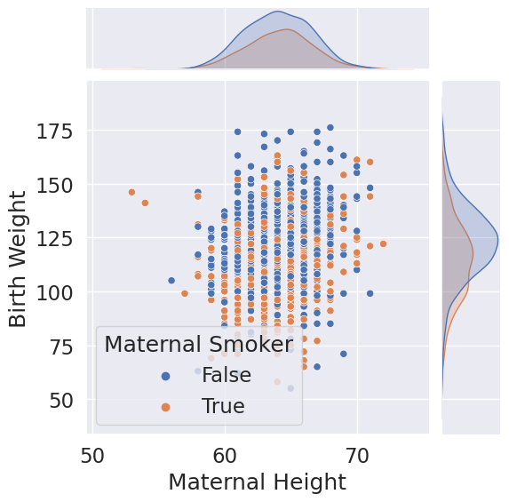

```python
sns.jointplot(data = births, x = 'Maternal Height', y = 'Birth Weight', hue = 'Maternal Smoker');
```

## Hex plots and contour plots

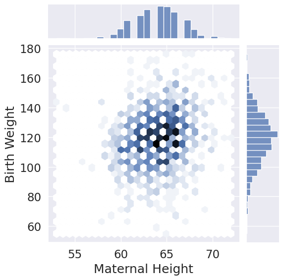

```python
sns.jointplot(data = births, x = 'Maternal Height', y = 'Birth Weight', kind = 'hex');
```

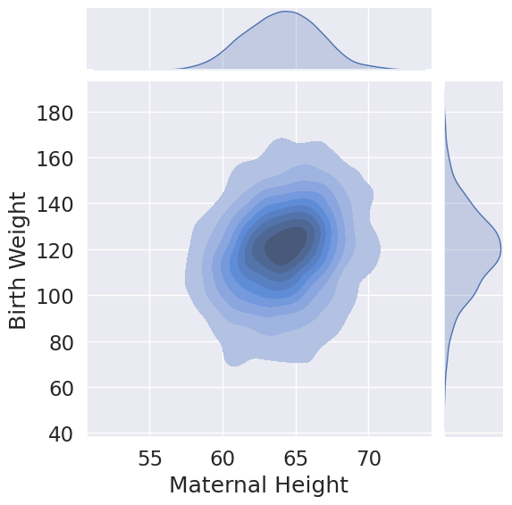

```python
sns.jointplot(data = births, x = 'Maternal Height', y = 'Birth Weight', kind = 'kde', fill = True);
```

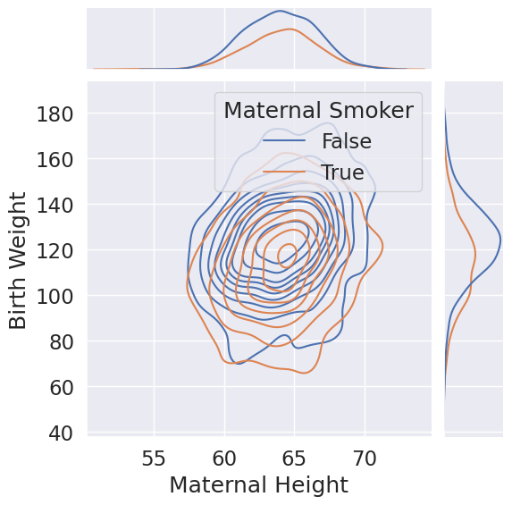

```python
sns.jointplot(data = births, x = 'Maternal Height', y = 'Birth Weight', kind = 'kde', hue = 'Maternal Smoker');
```

# Transformations Demo

## Kepler's Third Law

Details and data [can be found on Wikipedia](https://en.wikipedia.org/wiki/Kepler%27s_laws_of_planetary_motion#Third_law_of_Kepler).

```python
planets = pd.read_csv("data/planets.data", delim_whitespace=True, comment="#")
planets
```

|  | planet | mean_dist | period | kepler_ratio |
| --- | --- | --- | --- | --- |
| 0 | Mercury | 0.389 | 87.77 | 7.64 |
| 1 | Venus | 0.724 | 224.70 | 7.52 |
| 2 | Earth | 1.000 | 365.25 | 7.50 |
| 3 | Mars | 1.524 | 686.95 | 7.50 |
| 4 | Jupiter | 5.200 | 4332.62 | 7.49 |
| 5 | Saturn | 9.510 | 10759.20 | 7.43 |

Returning the `ax` Matplotlib axis object lets us specify the titles and labels manually.

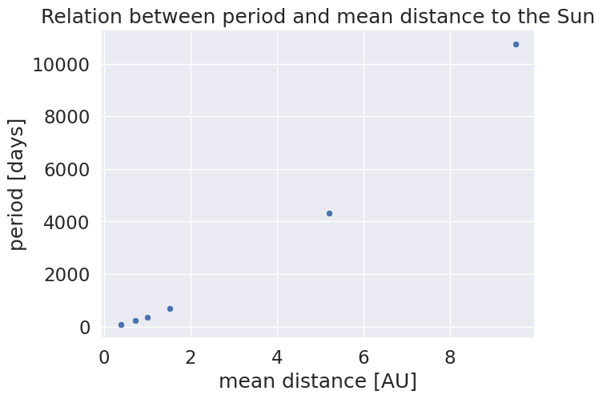

```python
ax = sns.scatterplot(x='mean_dist', y='period', data=planets);
ax.set_title('Relation between period and mean distance to the Sun')
ax.set_xlabel('mean distance [AU]')
ax.set_ylabel('period [days]');
```

The data appears to curve up, i.e. is not linear. We can verify this by trying the `regplot` function, which fits a line to the data (more on this function in a later lecture).

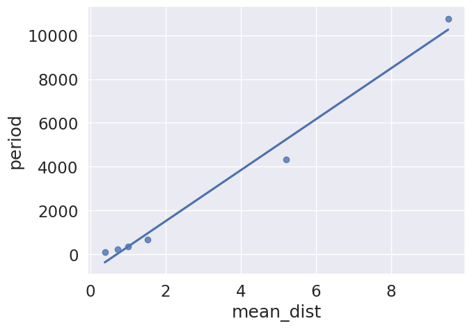

```python
sns.regplot(x='mean_dist', y='period', data=planets, ci=False);
```

However, if we plot the **log-log relationship**, we see a very linear looking relationship.

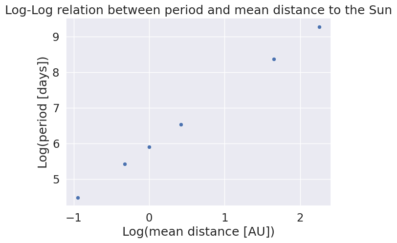

```python
ax = sns.scatterplot(x=np.log(planets['mean_dist']), y=np.log(planets['period']))

ax.set_title('Log-Log relation between period and mean distance to the Sun')
ax.set_xlabel('Log(mean distance [AU])')
ax.set_ylabel('Log(period [days])');
```

This time if we use `regplot`, the plot looks almost perfect.

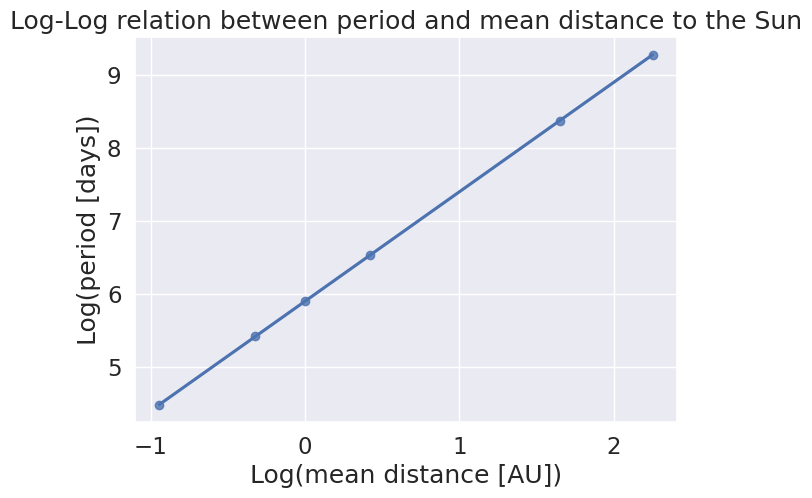

```python
ax = sns.regplot(x=np.log(planets['mean_dist']), y=np.log(planets['period']), ci=False)

ax.set_title('Log-Log relation between period and mean distance to the Sun')
ax.set_xlabel('Log(mean distance [AU])')
ax.set_ylabel('Log(period [days])');
```

The slope of this line is approximately (9 - 6) / 2 = **1.5**.

This suggests that the relationship between $T$ and $R$ is: $$T \propto R^{3/2}.$$

Kepler's third law actually states this in a slightly different format by squaring both sides:

$$ T^2\propto R^3 $$

For Kepler this was a data-driven phenomenological law, formulated in 1619. It could only be explained dynamically once Newton introduced his law of universal gravitation in 1687.